# Week 2 Assignment

Put your name here

6/21/2017

## Question 1

For the `patient_encounter` table, produce a data dictionary (you can use the format above in the `week2submission.nb.html`, or save it as an excel file). Submit your data dictionary as part of the assignment.

```r
##show the code you used to find this answer here
library(RSQLite)
library(here)
library(tidyverse)
#start our connection to the database
con <- DBI::dbConnect(RSQLite::SQLite(), here("data/patient1.sqlite"))

patient_encounter <- tbl(src=con, from="patient_encounter")
patient_encounter <- collect(patient_encounter)
dbDisconnect(con)
```

*Run `summary()` - are there any `character` or `numeric` variables that might be categories? Recast them as `factors` by using `mutate`.*

Let’s look at the first few rows of the table first.

```r
patient_encounter[1:10,]
```

```
## # A tibble: 10 x 13
##    patientID num_att_visits     i Scheduled_date Actual_date encounter_type
##        <int>          <int> <int> <chr>          <chr>                <int>
##  1         1             17     1 2013-10-15     2013-10-15               3
##  2         1             17     2 2013-12-01     2013-12-01               3
##  3         1             17     3 2013-05-01     2013-05-01               3
##  4         1             17     4 2013-09-04     2013-09-04               3
##  5         1             17     5 2013-11-23     2013-11-23               3
##  6         1             17     6 2013-06-11     2013-06-11               3
##  7         1             17     7 2013-09-02     2013-09-02               3
##  8         1             17     8 2013-10-31     2013-10-31               3
##  9         1             17     9 2013-12-08     2013-12-08               3
## 10         1             17    10 2013-02-02     2013-02-02               3
## # ... with 7 more variables: call_attemtps <int>, call_length <int>,
## #   number_phone_calls <int>, Scheduled_time <chr>, notes <chr>,
## #   reason <int>, Outcome <chr>
```

```r
summary(patient_encounter)
```

```
##    patientID     num_att_visits         i          Scheduled_date
##  Min.   :    1   Min.   :  0.00   Min.   :  1.00   Length:488438
##  1st Qu.: 8519   1st Qu.: 10.00   1st Qu.:  3.00   Class :character
##  Median :17276   Median : 21.00   Median :  8.00   Mode  :character
##  Mean   :17238   Mean   : 24.74   Mean   : 12.38
##  3rd Qu.:25920   3rd Qu.: 35.00   3rd Qu.: 18.00
##  Max.   :34532   Max.   :105.00   Max.   :105.00
##
##  Actual_date        encounter_type   call_attemtps    call_length
##  Length:488438      Min.   : 3.000   Min.   :0       Min.   : 0.00
##  Class :character   1st Qu.: 3.000   1st Qu.:0       1st Qu.: 3.00
##  Mode  :character   Median : 3.000   Median :1       Median : 7.00
##                     Mean   : 6.204   Mean   :1       Mean   : 7.01
##                     3rd Qu.: 3.000   3rd Qu.:2       3rd Qu.:11.00
##                     Max.   :48.000   Max.   :2       Max.   :14.00
##                                      NA's   :34773   NA's   :34773
##  number_phone_calls Scheduled_time        notes               reason
##  Min.   :2          Length:488438      Length:488438      Min.   :  0.00
##  1st Qu.:2          Class :character   Class :character   1st Qu.: 29.00
##  Median :2          Mode  :character   Mode  :character   Median : 59.00
##  Mean   :2                                                Mean   : 57.51
##  3rd Qu.:2                                                3rd Qu.: 88.00
##  Max.   :2                                                Max.   :109.00
##  NA's   :34773
##    Outcome
##  Length:488438
##  Class :character
##  Mode  :character
##
##
##
##
```

Looking at this summary, there appear to a few possible categorical variables: `encounter_type`, `reason`, and `Outcome`. So we’re going to cast those as `factors`.

```r
patient_encounter <- patient_encounter %>% mutate(encounter_type = factor(encounter_type),
                                                  reason = factor(reason),
                                                  Outcome = factor(Outcome),
                                                  notes=factor(notes))

summary(patient_encounter)
```

```
##    patientID     num_att_visits         i          Scheduled_date
##  Min.   :    1   Min.   :  0.00   Min.   :  1.00   Length:488438
##  1st Qu.: 8519   1st Qu.: 10.00   1st Qu.:  3.00   Class :character
##  Median :17276   Median : 21.00   Median :  8.00   Mode  :character
##  Mean   :17238   Mean   : 24.74   Mean   : 12.38
##  3rd Qu.:25920   3rd Qu.: 35.00   3rd Qu.: 18.00
##  Max.   :34532   Max.   :105.00   Max.   :105.00
##
##  Actual_date        encounter_type call_attemtps    call_length
##  Length:488438      3 :453665      Min.   :0       Min.   : 0.00
##  Class :character   48: 34773      1st Qu.:0       1st Qu.: 3.00
##  Mode  :character                  Median :1       Median : 7.00
##                                    Mean   :1       Mean   : 7.01
##                                    3rd Qu.:2       3rd Qu.:11.00
##                                    Max.   :2       Max.   :14.00
##                                    NA's   :34773   NA's   :34773
##  number_phone_calls Scheduled_time     notes          reason
##  Min.   :2          Length:488438      D:488438   97     : 38906
##  1st Qu.:2          Class :character              52     :  4313
##  Median :2          Mode  :character              90     :  4282
##  Mean   :2                                        81     :  4274
##  3rd Qu.:2                                        68     :  4261
##  Max.   :2                                        47     :  4258
##  NA's   :34773                                    (Other):428144
##      Outcome
##          :   293
##  COMPLETE:447282
##  NO SHOW : 40863
##
##
##
##
```

Huh. What’s `i`? I’m not sure, but I think it is an encounter number for individual patients. Let’s pull out a couple of patients and see if this is the case.

```r
table(patient_encounter$i)
```

```
##
##     1     2     3     4     5     6     7     8     9    10    11    12
## 67344 45212 33020 27208 23787 21298 19345 17709 16276 15190 14081 13047
##    13    14    15    16    17    18    19    20    21    22    23    24
## 12164 11264 10517  9739  9074  8462  7889  7409  6974  6524  6037  5608
##    25    26    27    28    29    30    31    32    33    34    35    36
##  5207  4813  4490  4212  3945  3650  3368  3101  2871  2653  2457  2297
##    37    38    39    40    41    42    43    44    45    46    47    48
##  2127  1985  1858  1750  1648  1545  1472  1354  1278  1206  1113  1016
##    49    50    51    52    53    54    55    56    57    58    59    60
##   942   880   843   781   717   674   623   574   529   473   420   363
##    61    62    63    64    65    66    67    68    69    70    71    72
##   321   282   239   217   194   185   168   165   162   155   135   131
##    73    74    75    76    77    78    79    80    81    82    83    84
##   127   114   112   107   101    92    83    74    71    70    61    61
##    85    86    87    88    89    90    91    92    93    94    95    96
##    59    55    55    51    50    50    48    48    47    41    31    26
##    97    98    99   100   101   102   103   104   105
##    11     9     3     3     3     3     2     2     1
```

Note this is mostly for show, since I didn’t show you how to use the `filter()` function. But if we look at these tables, it does appear to be the encounter number within each patient.

```r
patient_encounter %>% filter(patientID == 1) %>% head()
```

```
## # A tibble: 6 x 13
##   patientID num_att_visits     i Scheduled_date Actual_date encounter_type
##       <int>          <int> <int> <chr>          <chr>       <fct>
## 1         1             17     1 2013-10-15     2013-10-15  3
## 2         1             17     2 2013-12-01     2013-12-01  3
## 3         1             17     3 2013-05-01     2013-05-01  3
## 4         1             17     4 2013-09-04     2013-09-04  3
## 5         1             17     5 2013-11-23     2013-11-23  3
## 6         1             17     6 2013-06-11     2013-06-11  3
## # ... with 7 more variables: call_attemtps <int>, call_length <int>,
## #   number_phone_calls <int>, Scheduled_time <chr>, notes <fct>,
## #   reason <fct>, Outcome <fct>
```

```r
patient_encounter %>% filter(patientID == 3500) %>% head()
```

```
## # A tibble: 6 x 13
##   patientID num_att_visits     i Scheduled_date Actual_date encounter_type
##       <int>          <int> <int> <chr>          <chr>       <fct>
## 1      3500             31     1 2013-05-24     2013-05-24  3
## 2      3500             31     2 2013-12-10     2013-12-10  3
## 3      3500             31     3 2013-06-15     2013-06-15  3
## 4      3500             31     4 2013-11-15     2013-11-15  3
## 5      3500             31     5 2013-11-15     2013-11-15  3
## 6      3500             31     6 2013-09-06     2013-09-06  3
## # ... with 7 more variables: call_attemtps <int>, call_length <int>,
## #   number_phone_calls <int>, Scheduled_time <chr>, notes <fct>,
## #   reason <fct>, Outcome <fct>
```

```r
patient_encounter %>% filter(patientID == 3500) %>% nrow()
```

```
## [1] 31
```

Huh. The number of rows for each patient appears to equal `num_att_visits`. Is this always the case?

What about the `NO_SHOW` encounters? I’m going to filter by those patients who have `NO SHOW` and pick one of them. Patient 17 has a lot of num_att_visits, so I’m going to compare the two.

```r
patient_encounter %>% filter(Outcome == "NO SHOW") %>% head()
```

```
## # A tibble: 6 x 13
##   patientID num_att_visits     i Scheduled_date Actual_date encounter_type
##       <int>          <int> <int> <chr>          <chr>       <fct>
## 1         5              4     1 2013-08-28     20NA-NA-NA  3
## 2         8             29     1 2013-06-19     20NA-NA-NA  3
## 3         8             29     2 2013-11-25     20NA-NA-NA  3
## 4         9             19     1 2013-08-11     20NA-NA-NA  3
## 5        11             15     1 2013-01-28     20NA-NA-NA  3
## 6        17             40     1 2013-09-22     20NA-NA-NA  3
## # ... with 7 more variables: call_attemtps <int>, call_length <int>,
## #   number_phone_calls <int>, Scheduled_time <chr>, notes <fct>,
## #   reason <fct>, Outcome <fct>
```

```r
patient_encounter %>% filter(patientID == 17) %>% nrow()
```

```
## [1] 46
```

Huh. So the number of rows is not equal to the number in `num_att_visits`. So this value must be the number of visits the patient actually attended. Let’s confirm:

```r
pat_17 <- patient_encounter %>% filter(patientID == 17)
table(pat_17$Outcome)
```

```
##
##          COMPLETE  NO SHOW
##        0       42        4
```

Huh. This doesn’t completely seem to confirm our guess. We’ll have to follow up with our data engineers.

*Produce a visual summary (visdat) and a skimr summary of the data. Are there any things you notice about this table?*

Since the `patient_encounter` table is so huge, we’re going to sample from it.

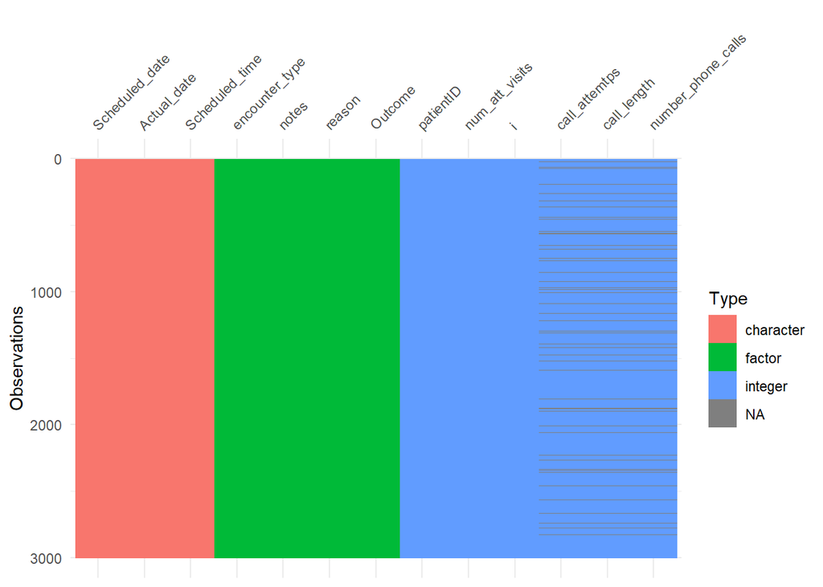

```r
library(visdat)
sampled_rows <- sample(1:nrow(patient_encounter), 3000)
vis_dat(patient_encounter[sampled_rows,])
```

In terms of missingness, there are only three categories where there appears to be missing data: `call_attempts`, `call_length`, and `number_phone_calls`.

```r
skimr::skim(patient_encounter)
```

```
## Skim summary statistics
##  n obs: 488438
##  n variables: 13
##
## -- Variable type:character ----------------------------------------------------------------------
##        variable missing complete      n min max empty n_unique
##     Actual_date       0   488438 488438  10  10     0      366
##  Scheduled_date       0   488438 488438  10  10     0      366
##  Scheduled_time       0   488438 488438   0   8 34773      473
##
## -- Variable type:factor -------------------------------------------------------------------------
##        variable missing complete      n n_unique
##  encounter_type       0   488438 488438        2
##           notes       0   488438 488438        1
##         Outcome       0   488438 488438        3
##          reason       0   488438 488438      110
##                                top_counts ordered
##               3: 453665, 48: 34773, NA: 0   FALSE
##                          D: 488438, NA: 0   FALSE
##  COM: 447282, NO : 40863, emp: 293, NA: 0   FALSE
##   97: 38906, 52: 4313, 90: 4282, 81: 4274   FALSE
##
## -- Variable type:integer ------------------------------------------------------------------------
##            variable missing complete      n     mean       sd p0  p25
##       call_attemtps   34773   453665 488438     1        0.82  0    0
##         call_length   34773   453665 488438     7.01     4.32  0    3
##                   i       0   488438 488438    12.38    13.07  1    3
##      num_att_visits       0   488438 488438    24.74    19.02  0   10
##  number_phone_calls   34773   453665 488438     2        0     2    2
##           patientID       0   488438 488438 17237.68 10007.09  1 8519
##      p50   p75  p100     hist
##      1       2     2 ▇▁▁▇▁▁▁▇
##      7      11    14 ▇▇▇▇▅▇▇▇
##      8      18   105 ▇▂▁▁▁▁▁▁
##     21      35   105 ▇▇▅▂▂▁▁▁
##      2       2     2 ▁▁▁▇▁▁▁▁
##  17275.5 25920 34532 ▇▇▇▇▇▇▇▇
```

*Add your data dictionary here, or submit as an excel file.*

## Question 2

*How many `No shows` were there in the dataset? (Look in the `outcome` variable).*

There are lots of different ways to identify the number of `NO SHOWS` in the `patient_encounter` table. Any of these ways is acceptable The first is just to use `summary()`:

```r
summary(patient_encounter)
```

```
##    patientID     num_att_visits         i          Scheduled_date
##  Min.   :    1   Min.   :  0.00   Min.   :  1.00   Length:488438
##  1st Qu.: 8519   1st Qu.: 10.00   1st Qu.:  3.00   Class :character
##  Median :17276   Median : 21.00   Median :  8.00   Mode  :character
##  Mean   :17238   Mean   : 24.74   Mean   : 12.38
##  3rd Qu.:25920   3rd Qu.: 35.00   3rd Qu.: 18.00
##  Max.   :34532   Max.   :105.00   Max.   :105.00
##
##  Actual_date        encounter_type call_attemtps    call_length
##  Length:488438      3 :453665      Min.   :0       Min.   : 0.00
##  Class :character   48: 34773      1st Qu.:0       1st Qu.: 3.00
##  Mode  :character                  Median :1       Median : 7.00
##                                    Mean   :1       Mean   : 7.01
##                                    3rd Qu.:2       3rd Qu.:11.00
##                                    Max.   :2       Max.   :14.00
##                                    NA's   :34773   NA's   :34773
##  number_phone_calls Scheduled_time     notes          reason
##  Min.   :2          Length:488438      D:488438   97     : 38906
##  1st Qu.:2          Class :character              52     :  4313
##  Median :2          Mode  :character              90     :  4282
##  Mean   :2                                        81     :  4274
##  3rd Qu.:2                                        68     :  4261
##  Max.   :2                                        47     :  4258
##  NA's   :34773                                    (Other):428144
##      Outcome
##          :   293
##  COMPLETE:447282
##  NO SHOW : 40863
##
##
##
##
```

You can also call `table()` on the `Outcome` variable in `patient_encounter`:

```r
table(patient_encounter$Outcome)
```

```
##
##          COMPLETE  NO SHOW
##      293   447282    40863
```

## Question 3

*We will want to predict 30 day readmissions in our dataset, which means that we want to predict whether a patient will be readmitted to the hospital within 30 days of being readmitted.

There are multiple reasons for a patient being readmission, but we’re interested in the ones that we can prevent. If we want to count the number of readmissions, would we want to include patients who are just `No shows`?*

Answer (no need to show code here):

I’m going to add some context to why we are interested in 30 day hospital readmissions. Hopefully this will give you a better understanding of why we are interested in them.

### Hospital Readmission Definition

In our class, we will define a hospital readmission as a patient readmitted to the hospital within 30 days of a previous hospital admission.

### Why Are We Interested in Hospital Readmissions?

Hospital readmissions can happen for a number of reasons:

1. The patient was scheduled for a routine procedure that happens within 30 days for each other, such as chemotherapy. These are called *planned* readmissions.
2. The patient was readmitted for acute illness or because of complications of care. These are *unplanned* readmissions.

Ultimately, we’d like to target unplanned admission cases. These are the cases where the hospital can potentially intervene and improve outcomes. For example, if we identify those patients who have unplanned readmission potential, we can potentially provide better care for these patients to avoid a readmission.

In our dataset, we can’t distinguish between these two cases. But we still want to see if there are characteristics of *unplanned* readmission patients that we can use to identify these cases before they happen. We’ll do this in class by implementing something called the *LACE* score.

### `patient_encounter` versus `patient_encounter_hosp`

One thing: `patient_encounter` is actually *all* patient encounters in the health system, whereas `patient_encounter_hosp` is limited to only those patients in the hospital. So for the hospital readmission question, we actually want to look at `patient_encounter_hosp`. So we were technically looking in the wrong place.

My goal is really to get you to look at the data and start asking questions. Without examining the data, we may not understand that our assumptions were correct.

Take a look at the encounter types in `patient_encounter_hosp` versus those in `patient_encounter` (you can look up the codes in `t_encounter_type`). What do you notice?

### Identifying Hospital Readmissions

In order to identify our 30 day readmission cases, we will have to identify two dates from `patient_encounter_hosp`:

1. An initial admission (this is called the *index admission*) and
2. A admission date within 30 days of the index admission discharge date. (*readmission*)

### So what about “No Shows”?

The real answer: “No shows” are not really patient encounters. They are neither *index admission dates* nor *readmission dates*, so they are not useful to us.

It’s true that patients may have “No Shows” interspersed with the hospital readmissions, and you don’t want to exclude patients from the readmission calculation just because they have “No Shows”. That was a fair assumption if you made it.